# Data Preprocessing

#### 2.2.2 🔁 Covariance between numerical features.

```python
# Covariance for train data
display(Numeric_train_df.cov())
```

|  | policy_tenure | age_of_car | age_of_policyholder | population_density | make | airbags | displacement | cylinder | gear_box | turning_radius | gross_weight | ncap_rating | is_claim | torque_value | torque_rpm | power_value | power_rpm | car_volume |
| --- | --- | --- | --- | --- | --- | --- | --- | --- | --- | --- | --- | --- | --- | --- | --- | --- | --- | --- |
| policy_tenure | 1.715256e-01 | 3.906878e-03 | 7.312221e-03 | -7.336500e+02 | 4.054394e-02 | 7.892192e-02 | 2.143648e+01 | 3.829288e-02 | 1.698663e-02 | 1.571939e-02 | 1.240707e+01 | 9.972288e-02 | 7.980511e-03 | 4.562443e+00 | 5.939185e+00 | 2.376627e+00 | -3.837917e+01 | 1.434244e+08 |
| age_of_car | 3.906878e-03 | 3.217232e-03 | -2.469333e-04 | -6.236055e+01 | 1.213208e-02 | 2.173284e-02 | 5.939405e+00 | 1.041069e-02 | 4.920527e-03 | 4.303932e-03 | 3.640255e+00 | 2.749575e-02 | -3.910124e-04 | 1.280648e+00 | 7.246310e-01 | 6.437124e-01 | -1.105769e+01 | 3.950796e+07 |
| age_of_policyholder | 7.312221e-03 | -2.469333e-04 | 1.510094e-02 | 2.098321e+01 | -4.469424e-03 | -1.810775e-03 | -7.776774e-01 | 2.486043e-04 | -1.647493e-04 | -4.698209e-04 | -2.025194e-01 | -5.400726e-03 | 6.746277e-04 | -1.404534e-01 | 3.096121e+00 | -4.027939e-02 | 4.224900e+00 | -5.270565e+06 |
| population_density | -7.336500e+02 | -6.236055e+01 | 2.098321e+01 | 3.118818e+08 | -7.052829e+02 | -1.953491e+03 | -4.278940e+05 | -7.822553e+02 | -4.304685e+02 | -3.121431e+02 | -2.919225e+05 | -1.746038e+03 | -7.695699e+01 | -9.697697e+04 | -9.270259e+03 | -4.729218e+04 | 7.963930e+05 | -2.995242e+12 |
| make | 4.054394e-02 | 1.213208e-02 | -4.469424e-03 | -7.052829e+02 | 1.292741e+00 | 1.045597e+00 | 2.281015e+02 | 2.258141e-01 | 3.096365e-01 | 1.954780e-01 | 1.162708e+02 | 1.251707e+00 | -1.268129e-04 | 6.901508e+01 | -6.380214e+02 | 2.027582e+01 | -9.674239e+02 | 1.228288e+09 |
| airbags | 7.892192e-02 | 2.173284e-02 | -1.810775e-03 | -1.953491e+03 | 1.045597e+00 | 3.358574e+00 | 3.226881e+02 | 4.241754e-01 | 6.779172e-01 | 3.388851e-01 | 3.227211e+02 | 8.698066e-01 | 1.250615e-03 | 1.072962e+02 | -5.645199e+02 | 3.525948e+01 | -1.126199e+03 | 2.465002e+09 |
| displacement | 2.143648e+01 | 5.939405e+00 | -7.776774e-01 | -4.278940e+05 | 2.281015e+02 | 3.226881e+02 | 7.091824e+04 | 1.115613e+02 | 7.933422e+01 | 5.316670e+01 | 4.390962e+04 | 3.134573e+02 | 5.003204e-01 | 1.813981e+04 | -7.964163e+04 | 7.100760e+03 | -1.941444e+05 | 4.397611e+11 |
| cylinder | 3.829288e-02 | 1.041069e-02 | 2.486043e-04 | -7.822553e+02 | 2.258141e-01 | 4.241754e-01 | 1.115613e+02 | 2.338845e-01 | 8.536548e-02 | 6.791964e-02 | 6.194467e+01 | 4.021135e-01 | 1.589727e-03 | 2.426239e+01 | -1.397521e+01 | 1.173289e+01 | -1.852543e+02 | 6.653051e+08 |
| gear_box | 1.698663e-02 | 4.920527e-03 | -1.647493e-04 | -4.304685e+02 | 3.096365e-01 | 6.779172e-01 | 7.933422e+01 | 8.536548e-02 | 1.852039e-01 | 8.457694e-02 | 8.178516e+01 | 3.167578e-01 | -6.691477e-05 | 2.786556e+01 | -1.844840e+02 | 8.491781e+00 | -3.115464e+02 | 6.068292e+08 |
| turning_radius | 1.571939e-02 | 4.303932e-03 | -4.698209e-04 | -3.121431e+02 | 1.954780e-01 | 3.388851e-01 | 5.316670e+01 | 6.791964e-02 | 8.457694e-02 | 5.201174e-02 | 3.987524e+01 | 2.469669e-01 | 1.520278e-04 | 1.579031e+01 | -6.950190e+01 | 5.663043e+00 | -1.743174e+02 | 3.598327e+08 |
| gross_weight | 1.240707e+01 | 3.640255e+00 | -2.025194e-01 | -2.919225e+05 | 1.162708e+02 | 3.227211e+02 | 4.390962e+04 | 6.194467e+01 | 8.178516e+01 | 3.987524e+01 | 4.512357e+04 | 1.641987e+02 | 2.024288e-01 | 1.320842e+04 | -5.784859e+04 | 4.632151e+03 | -1.308629e+05 | 3.362843e+11 |
| ncap_rating | 9.972288e-02 | 2.749575e-02 | -5.400726e-03 | -1.746038e+03 | 1.251707e+00 | 8.698066e-01 | 3.134573e+02 | 4.021135e-01 | 3.167578e-01 | 2.469669e-01 | 1.641987e+02 | 1.930923e+00 | 1.292123e-03 | 8.058153e+01 | -3.990609e+02 | 3.060815e+01 | -9.909449e+02 | 1.869988e+09 |
| is_claim | 7.980511e-03 | -3.910124e-04 | 6.746277e-04 | -7.695699e+01 | -1.268129e-04 | 1.250615e-03 | 5.003204e-01 | 1.589727e-03 | -6.691477e-05 | 1.520278e-04 | 2.024288e-01 | 1.292123e-03 | 5.987692e-02 | 7.685973e-02 | 8.492130e-01 | 5.217360e-02 | 2.138083e-02 | 2.545279e+06 |
| torque_value | 4.562443e+00 | 1.280648e+00 | -1.404534e-01 | -9.697697e+04 | 6.901508e+01 | 1.072962e+02 | 1.813981e+04 | 2.426239e+01 | 2.786556e+01 | 1.579031e+01 | 1.320842e+04 | 8.058153e+01 | 7.685973e-02 | 5.350453e+03 | -3.195721e+04 | 1.819975e+03 | -6.116252e+04 | 1.179510e+11 |
| torque_rpm | 5.939185e+00 | 7.246310e-01 | 3.096121e+00 | -9.270259e+03 | -6.380214e+02 | -5.645199e+02 | -7.964163e+04 | -1.397521e+01 | -1.844840e+02 | -6.950190e+01 | -5.784859e+04 | -3.990609e+02 | 8.492130e-01 | -3.195721e+04 | 5.270189e+05 | -4.807633e+03 | 5.489249e+05 | -4.444377e+11 |
| power_value | 2.376627e+00 | 6.437124e-01 | -4.027939e-02 | -4.729218e+04 | 2.027582e+01 | 3.525948e+01 | 7.100760e+03 | 1.173289e+01 | 8.491781e+00 | 5.663043e+00 | 4.632151e+03 | 3.060815e+01 | 5.217360e-02 | 1.819975e+03 | -4.807633e+03 | 7.672489e+02 | -1.739869e+04 | 4.620307e+10 |
| power_rpm | -3.837917e+01 | -1.105769e+01 | 4.224900e+00 | 7.963930e+05 | -9.674239e+02 | -1.126199e+03 | -1.941444e+05 | -1.852543e+02 | -3.115464e+02 | -1.743174e+02 | -1.308629e+05 | -9.909449e+02 | 2.138083e-02 | -6.116252e+04 | 5.489249e+05 | -1.739869e+04 | 8.404687e+05 | -1.202567e+12 |
| car_volume | 1.434244e+08 | 3.950796e+07 | -5.270565e+06 | -2.995242e+12 | 1.228288e+09 | 2.465002e+09 | 4.397611e+11 | 6.653051e+08 | 6.068292e+08 | 3.598327e+08 | 3.362843e+11 | 1.869988e+09 | 2.545279e+06 | 1.179510e+11 | -4.444377e+11 | 4.620307e+10 | -1.202567e+12 | 3.057072e+18 |

#### 2.2.3 🕵️Comparison with features

**1. Numeric Features Vs Target feature(is_claim)**

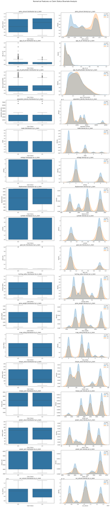

```python
dp.plot_numerical_vs_target(train_df, Numeric_train_features)
```

Key Insights: Most Predictive Numeric Features(Might Be):

- policy_tenure
- age_of_policyholder
- population_density
- displacement
- gross_weight
- ncap_rating
- power
- turning_radius
- airbags
- torque_value
- power_value

Least Predictive Features(Might Be):

- cylinder
- gear_box
- make
- car_volume
- torque_rpm
- power_rpm

**2. Categorical Features Vs Target feature(is_claim)**

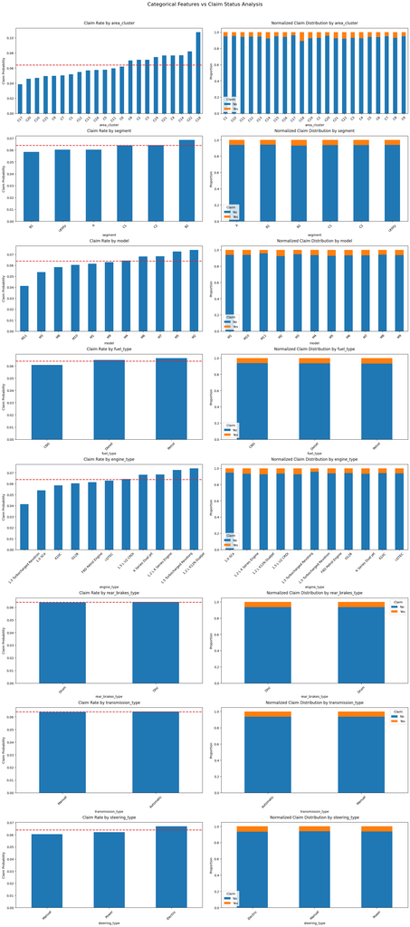

```python
dp.plot_categorical_vs_target(train_df, Categorical_train_features)
```

Most Predictive Categorical Features(Might Be):

- area_cluster
- model
- segment
- engine_type

Least Predictive Features(Might Be):

- steering_type
- transmission_type
- fuel_type
- rear_brakes_type

**3. Boolean Features Vs Target feature(is_claim)**

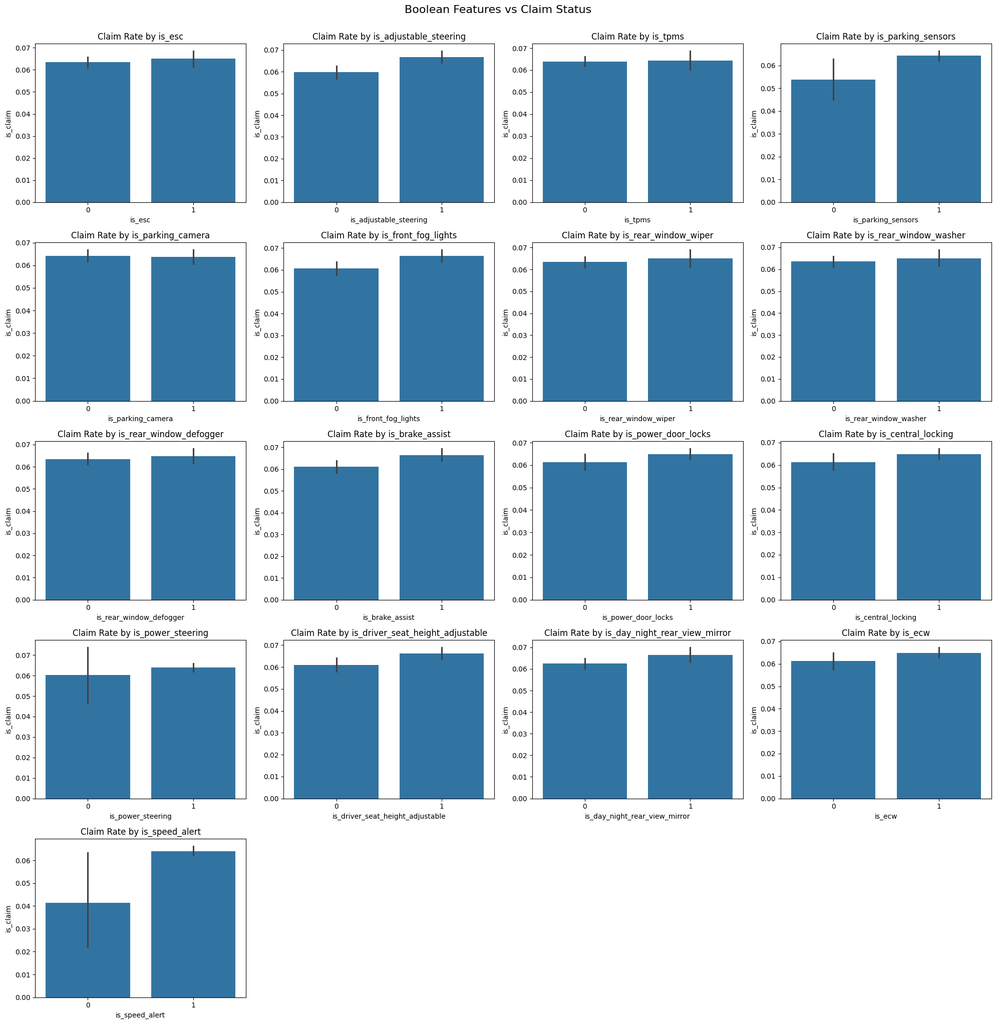

```python
dp.plot_boolean_vs_target(train_df, Boolean_train_features)
```

Most Predictive Binary Features(Might Be):

- is_brake_assist
- is_power_door_locks
- is_driver_seat_height_adjustable
- is_speed_alert
- is_ecw

**4. Age Analysis**

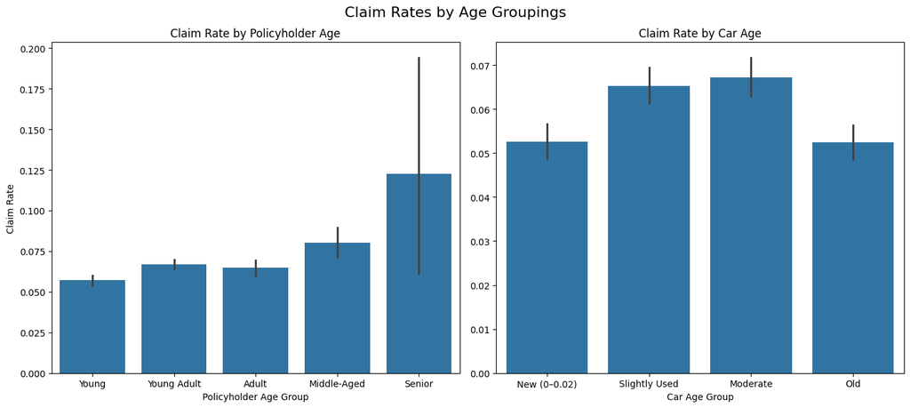

```python
dp.plot_grouped_age_vs_target(train_df)
```

**5. Power & Torque**

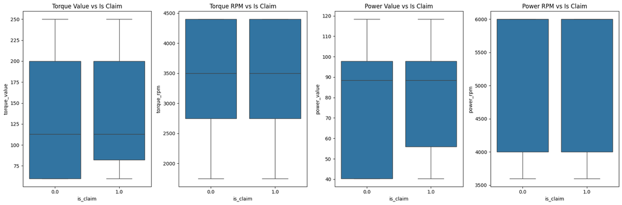

```python
fig, axes = plt.subplots(1, 4, figsize=(18, 6))

sns.boxplot(data=train_df, x='is_claim', y='torque_value', ax=axes[0])
axes[0].set_title('Torque Value vs Is Claim')

sns.boxplot(data=train_df, x='is_claim', y='torque_rpm', ax=axes[1])
axes[1].set_title('Torque RPM vs Is Claim')

sns.boxplot(data=train_df, x='is_claim', y='power_value', ax=axes[2])
axes[2].set_title('Power Value vs Is Claim')

sns.boxplot(data=train_df, x='is_claim', y='power_rpm', ax=axes[3])
axes[3].set_title('Power RPM vs Is Claim')

plt.tight_layout()
plt.show()
```

**6. Important Features Analysis (Numerical)**

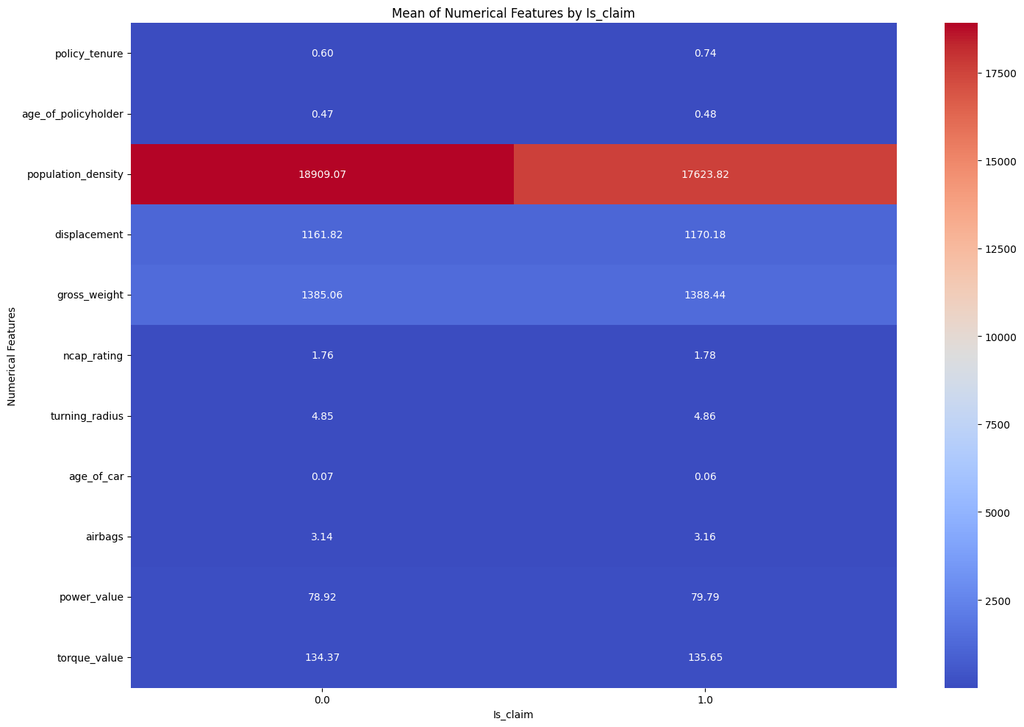

```python
num_features = ['policy_tenure','age_of_policyholder', 'population_density', 'displacement', 'gross_weight',
                'ncap_rating', 'turning_radius', 'age_of_car', 'airbags','power_value','torque_value']

dp.plot_grouped_means_heatmap(train_df, num_features)
```

**7. Important Feature Analysis (Categorical Features)**

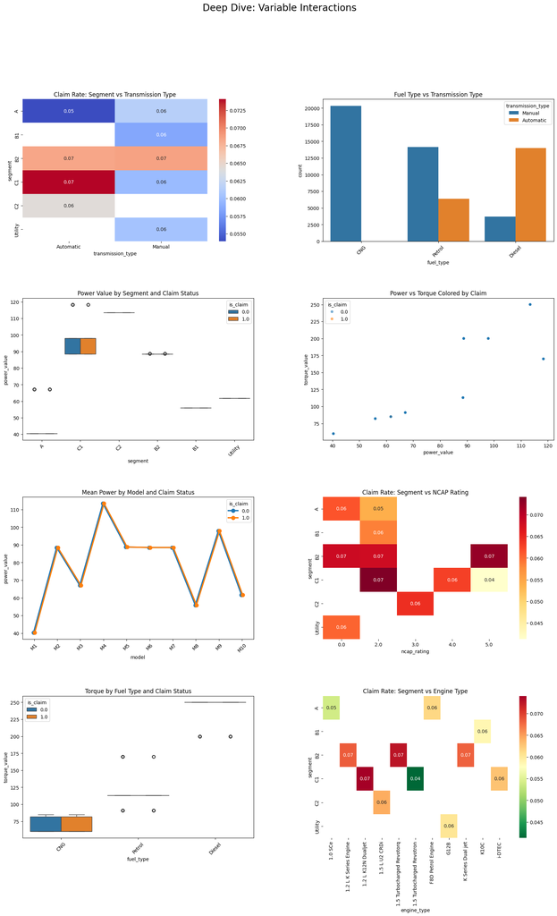

```python
dp.deep_dive_variable_interactions(train_df)
```

**8. Boolean Safety Features**

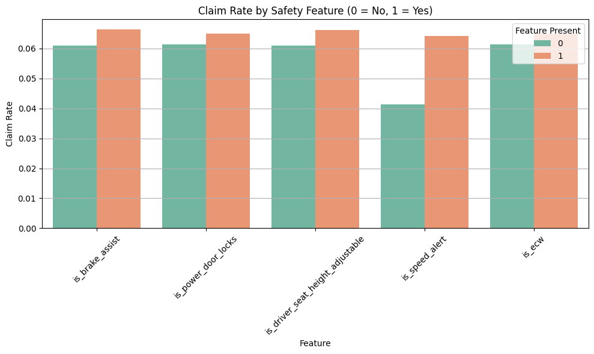

```python
bool_features = [
    'is_brake_assist',
    'is_power_door_locks',
    'is_driver_seat_height_adjustable',
    'is_speed_alert',
    'is_ecw'
]

dp.plot_boolean_feature_claim_rates(train_df, bool_features)
```

### 2.3 🌈Multivariate Analysis

**░ Pairwise plots for numerical columns.**

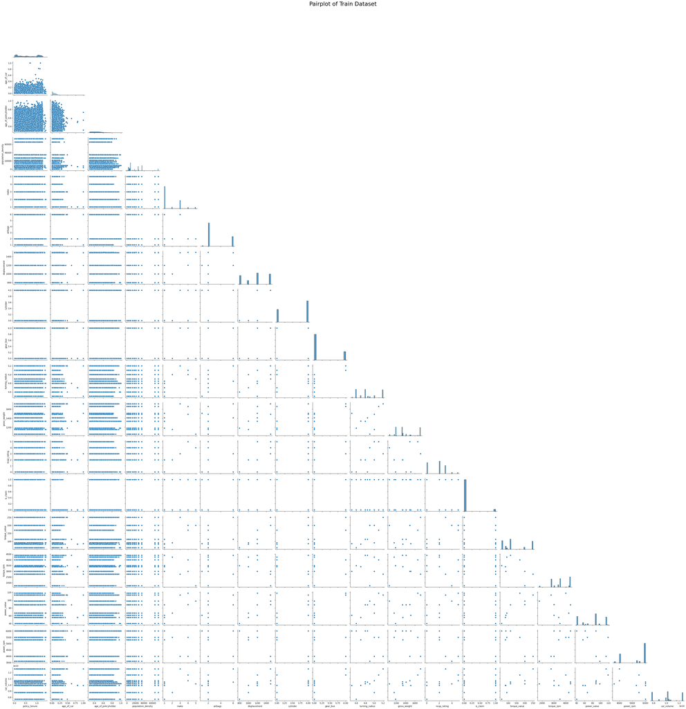

```python
# Pairplot for train data
sns.pairplot(Numeric_train_df, corner=True)
plt.suptitle("Pairplot of Train Dataset", y=1.02, fontsize=26)
plt.show()
```

#### 2.3.2 ✅ Principal Component Analysis (PCA)

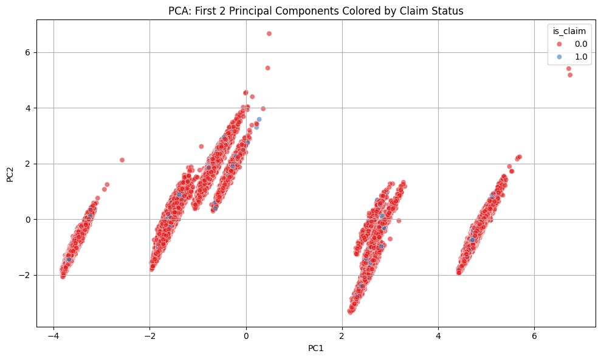

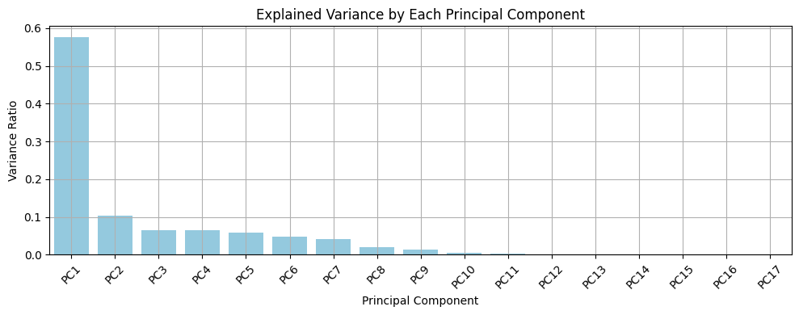

```
Cumulative variance by PC1 to PC1: 0.5766
Cumulative variance by PC1 to PC2: 0.6803
Cumulative variance by PC1 to PC3: 0.7455
Cumulative variance by PC1 to PC4: 0.8104
Cumulative variance by PC1 to PC5: 0.8687
Cumulative variance by PC1 to PC6: 0.9156
Cumulative variance by PC1 to PC7: 0.9573
Cumulative variance by PC1 to PC8: 0.9770
Cumulative variance by PC1 to PC9: 0.9905
Cumulative variance by PC1 to PC10: 0.9953
Cumulative variance by PC1 to PC11: 0.9978
Cumulative variance by PC1 to PC12: 0.9992
Cumulative variance by PC1 to PC13: 1.0000
Cumulative variance by PC1 to PC14: 1.0000
Cumulative variance by PC1 to PC15: 1.0000
Cumulative variance by PC1 to PC16: 1.0000
Cumulative variance by PC1 to PC17: 1.0000
```

[output not shown]

```python
dp.run_pca(train_df, target_col='is_claim', n_components=2)
```

#### 2.3.3 ✅ Clustering analysis

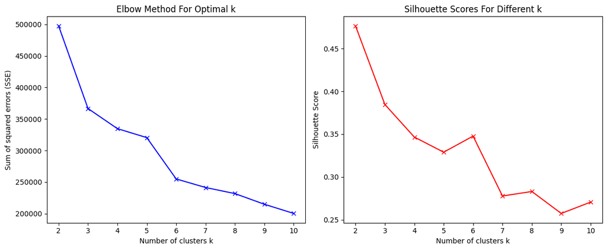

```
Best k by silhouette score: 2
```

```python
# Find best k for K-Means
dp.find_best_k_elbow_silhouette(train_df, target_col='is_claim')
```

**1. K-Means Cluster**

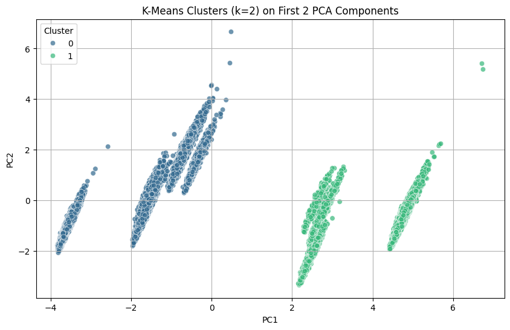

```
Cluster vs Target Crosstab:
is_claim    0.0   1.0
Cluster
0         37916  2583
1         16928  1165
Silhouette Score for k=2: 0.477
```

```
(KMeans(n_clusters=2, random_state=42),
 PCA(n_components=2),
 array([0, 0, 0, ..., 0, 0, 1], dtype=int32),
             PC1       PC2  Cluster  is_claim
 0     -3.531371 -0.727487        0       0.0
 1     -3.593446 -1.140202        0       0.0
 2     -3.530941 -0.855389        0       0.0
 3     -0.580851  2.061299        0       0.0
 4     -1.533074  0.076951        0       0.0
 ...         ...       ...      ...       ...
 58587 -1.482932  0.244479        0       0.0
 58588 -3.492795 -0.569938        0       0.0
 58589 -3.476702 -0.647752        0       0.0
 58590 -0.505793  2.610127        0       0.0
 58591  4.588598 -1.260753        1       0.0

 [58592 rows x 4 columns])
```

```python
# Run K-Means with chosen k
dp.run_kmeans(train_df, target_col='is_claim', n_clusters=2)
```

**2.DBSCAN**

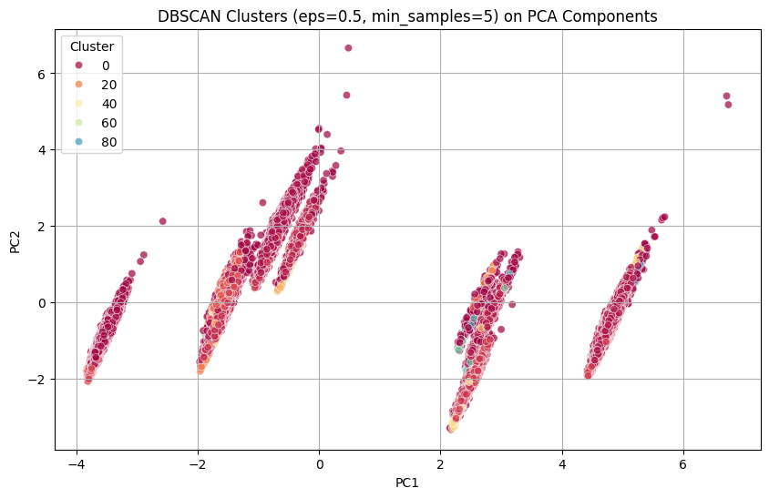

```
Cluster vs Target Crosstab (noise = -1):
is_claim    0.0  1.0
Cluster
-1         2295  128
 0        12522  823
 1        12956  987
 2        12312  868
 3         1102   95
...         ...  ...
 88           3    0
 89           5    0
 90           4    0
 91           5    0
 92           5    0

[94 rows x 2 columns]
```

```
(DBSCAN(),
 PCA(n_components=2),
 array([0, 0, 0, ..., 0, 1, 2]),
             PC1       PC2  Cluster  is_claim
 0     -3.531371 -0.727487        0       0.0
 1     -3.593446 -1.140202        0       0.0
 2     -3.530941 -0.855389        0       0.0
 3     -0.580851  2.061299        1       0.0
 4     -1.533074  0.076951       10       0.0
 ...         ...       ...      ...       ...
 58587 -1.482932  0.244479       10       0.0
 58588 -3.492795 -0.569938        0       0.0
 58589 -3.476702 -0.647752        0       0.0
 58590 -0.505793  2.610127        1       0.0
 58591  4.588598 -1.260753        2       0.0

 [58592 rows x 4 columns])
```

```python
# Run DBSCAN (tweak eps and min_samples if needed)
dp.run_dbscan(train_df, target_col='is_claim', eps=0.5, min_samples=5)
```

## **3. 🎨 Preprocessing (After EDA)**

```python
print(train_df.info())
```

```
<class 'pandas.core.frame.DataFrame'>
RangeIndex: 58592 entries, 0 to 58591
Data columns (total 43 columns):
 #   Column                            Non-Null Count  Dtype
---  ------                            --------------  -----
 0   policy_tenure                     58592 non-null  float64
 1   age_of_car                        58592 non-null  float64
 2   age_of_policyholder               58592 non-null  float64
 3   area_cluster                      58592 non-null  object
 4   population_density                58592 non-null  float64
 5   make                              58592 non-null  float64
 6   segment                           58592 non-null  object
 7   model                             58592 non-null  object
 8   fuel_type                         58592 non-null  object
 9   engine_type                       58592 non-null  object
```

[output cut: 36 more lines]

#### 3.1. 📌Handle Outliers

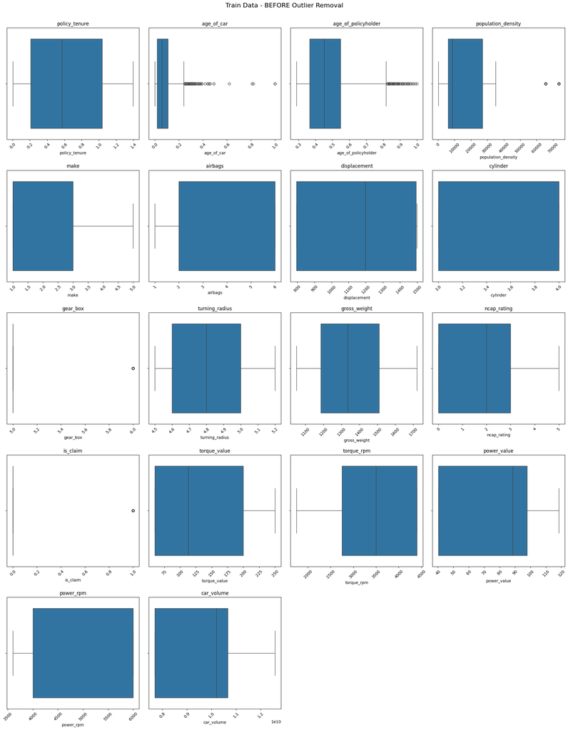

```python
# Example for train data
train_df = dp.handle_outliers(train_df, dataset_name='Train Data')
test_df = dp.handle_outliers(test_df, dataset_name='Test Data', show_plots=False)
```

From the boxplots, can be observe:

This suggests that:

- Outlier removal may not be necessary for this dataset.
- Removing them could risk discarding valid rare cases that are useful for modeling (especially for classification tasks like fraud or claim detection, where rare events matter).

#### 3.2 🛠️Encode categorical data

```python
# Check for outliers in train data
train_df = dp.encode_categorical_data(train_df)
train_df.info()
display(train_df.head())

# Check for outliers in test data
test_df = dp.encode_categorical_data(test_df)
test_df.info()
display(test_df.head())
```

```
<class 'pandas.core.frame.DataFrame'>
RangeIndex: 58592 entries, 0 to 58591
Data columns (total 43 columns):
 #   Column                            Non-Null Count  Dtype
---  ------                            --------------  -----
 0   policy_tenure                     58592 non-null  float64
 1   age_of_car                        58592 non-null  float64
 2   age_of_policyholder               58592 non-null  float64
 3   area_cluster                      58592 non-null  int64
 4   population_density                58592 non-null  float64
 5   make                              58592 non-null  int64
 6   segment                           58592 non-null  int64
 7   model                             58592 non-null  int64
 8   fuel_type                         58592 non-null  int64
 9   engine_type                       58592 non-null  int64
```

[output cut: 35 more lines]

|  | policy_tenure | age_of_car | age_of_policyholder | area_cluster | population_density | make | segment | model | fuel_type | engine_type | ... | is_day_night_rear_view_mirror | is_ecw | is_speed_alert | ncap_rating | is_claim | torque_value | torque_rpm | power_value | power_rpm | car_volume |
| --- | --- | --- | --- | --- | --- | --- | --- | --- | --- | --- | --- | --- | --- | --- | --- | --- | --- | --- | --- | --- | --- |
| 0 | 0.515874 | 0.05 | 0.644231 | 0 | 4990.0 | 0 | 0 | 0 | 0 | 6 | ... | 0 | 0 | 1 | 0.0 | 0.0 | 60.0 | 3500 | 40.36 | 6000 | 7.698283e+09 |
| 1 | 0.672619 | 0.02 | 0.375000 | 11 | 27003.0 | 0 | 0 | 0 | 0 | 6 | ... | 0 | 0 | 1 | 0.0 | 0.0 | 60.0 | 3500 | 40.36 | 6000 | 7.698283e+09 |
| 2 | 0.841110 | 0.02 | 0.384615 | 15 | 4076.0 | 0 | 0 | 0 | 0 | 6 | ... | 0 | 0 | 1 | 0.0 | 0.0 | 60.0 | 3500 | 40.36 | 6000 | 7.698283e+09 |
| 3 | 0.900277 | 0.11 | 0.432692 | 16 | 21622.0 | 0 | 3 | 3 | 2 | 2 | ... | 1 | 1 | 1 | 1.0 | 0.0 | 113.0 | 4400 | 88.50 | 6000 | 1.050096e+10 |
| 4 | 0.596403 | 0.11 | 0.634615 | 17 | 34738.0 | 1 | 0 | 4 | 2 | 0 | ... | 1 | 1 | 1 | 1.0 | 0.0 | 91.0 | 4250 | 67.06 | 5500 | 8.777961e+09 |

5 rows × 43 columns

```
<class 'pandas.core.frame.DataFrame'>
RangeIndex: 39063 entries, 0 to 39062
Data columns (total 42 columns):
 #   Column                            Non-Null Count  Dtype
---  ------                            --------------  -----
 0   policy_tenure                     39063 non-null  float64
 1   age_of_car                        39063 non-null  float64
 2   age_of_policyholder               39063 non-null  float64
 3   area_cluster                      39063 non-null  int64
 4   population_density                39063 non-null  float64
 5   make                              39063 non-null  int64
 6   segment                           39063 non-null  int64
 7   model                             39063 non-null  int64
 8   fuel_type                         39063 non-null  int64
 9   engine_type                       39063 non-null  int64
```

[output cut: 34 more lines]

|  | policy_tenure | age_of_car | age_of_policyholder | area_cluster | population_density | make | segment | model | fuel_type | engine_type | ... | is_driver_seat_height_adjustable | is_day_night_rear_view_mirror | is_ecw | is_speed_alert | ncap_rating | torque_value | torque_rpm | power_value | power_rpm | car_volume |
| --- | --- | --- | --- | --- | --- | --- | --- | --- | --- | --- | --- | --- | --- | --- | --- | --- | --- | --- | --- | --- | --- |
| 0 | 0.341732 | 0.00 | 0.586538 | 15 | 4076.0 | 0 | 0 | 0 | 0 | 6 | ... | 0 | 0 | 0 | 1 | 0.0 | 60.0 | 3500 | 40.36 | 6000 | 7.698283e+09 |
| 1 | 0.307241 | 0.13 | 0.442308 | 20 | 8794.0 | 0 | 2 | 7 | 2 | 8 | ... | 1 | 1 | 1 | 1 | 1.0 | 113.0 | 4400 | 88.50 | 6000 | 1.020674e+10 |
| 2 | 0.327924 | 0.12 | 0.451923 | 20 | 8794.0 | 1 | 0 | 4 | 2 | 0 | ... | 0 | 1 | 1 | 1 | 1.0 | 91.0 | 4250 | 67.06 | 5500 | 8.777961e+09 |
| 3 | 0.782654 | 0.01 | 0.461538 | 17 | 34738.0 | 0 | 0 | 0 | 0 | 6 | ... | 0 | 0 | 0 | 1 | 0.0 | 60.0 | 3500 | 40.36 | 6000 | 7.698283e+09 |
| 4 | 1.233404 | 0.02 | 0.634615 | 17 | 34738.0 | 0 | 0 | 0 | 0 | 6 | ... | 0 | 0 | 0 | 1 | 0.0 | 60.0 | 3500 | 40.36 | 6000 | 7.698283e+09 |

5 rows × 42 columns

In the dataset, the ordinal column 'ncap_rating' has been handled using label encoding, and the nominal categorical columns 'fuel_type', 'model', 'segment', 'area_cluster', 'engine_type', 'transmission_type', 'steering_type', and 'rear_brakes_type' have also been encoded with label encoding. Since tree-based models (such as Random Forest and XGBoost) do not rely on numeric relationships in encoded labels, label encoding is suitable for this setup. Binary columns were addressed during the initial feature engineering steps, which took place prior to exploratory data analysis (EDA), allowing insights to be gained through data visualization.

### 3.3. 🔄 Feature Scaling

```python
# Separate target
y_train = train_df['is_claim']
X_train = train_df.drop(columns='is_claim')

# Scale features
X_train, scaler = dp.scale_important_features(X_train)
```

```python
# Final scaling using scaler from training
X_test = dp.scale_important_features(test_df, scaler=scaler)
```

This step is designed to standardize selected numeric features to ensure fair contribution to machine learning models. Its primary goal is to apply consistent scaling to both training and test datasets, which is essential for models that are sensitive to feature magnitudes. The function uses StandardScaler, a technique that transforms features to have a mean of zero and a standard deviation of one ideal for features that are approximately normally distributed. By focusing on a set of domain relevant numeric columns, the function avoids unnecessary transformations and keeps the data preparation efficient. Additionally, it includes a safeguard by filtering out any columns that may have been dropped earlier in the pipeline, enhancing its robustness and preventing errors during execution.

## 4. ⚠️ Save Data

```python
# Save cleaned data
# Combine balanced features and labels back into a DataFrame
train_clean_df = pd.DataFrame(X_train, columns=X_train.columns)
train_clean_df['is_claim'] = y_train

# Save to CSV
train_clean_df.to_csv('../data/processed/cleaned_train_data.csv', index=False)
# Save test data
# Assuming test_df is already preprocessed (imputed, encoded, scaled)
test_clean_df = pd.DataFrame(X_test, columns=X_train.columns)  # Use same columns as X_train
assert list(test_clean_df.columns) == list(X_train.columns), "Feature mismatch between train and test sets!"

# Save to CSV
test_clean_df.to_csv('../data/processed/cleaned_test_data.csv', index=False)
```

```python
train_clean_df.info()
test_clean_df.info()
```

```
<class 'pandas.core.frame.DataFrame'>
RangeIndex: 58592 entries, 0 to 58591
Data columns (total 43 columns):
 #   Column                            Non-Null Count  Dtype
---  ------                            --------------  -----
 0   policy_tenure                     58592 non-null  float64
 1   age_of_car                        58592 non-null  float64
 2   age_of_policyholder               58592 non-null  float64
 3   area_cluster                      58592 non-null  int64
 4   population_density                58592 non-null  float64
 5   make                              58592 non-null  int64
 6   segment                           58592 non-null  int64
 7   model                             58592 non-null  int64
 8   fuel_type                         58592 non-null  int64
 9   engine_type                       58592 non-null  int64
```

[output cut: 84 more lines]

## ✅ Conclusion

Having completed data preprocessing, EDA, and preprocessing steps (such as handling outliers, encoding categorical data, and scaling features). The cleaned data such as cleaned_train_data and cleaned_test_data has been saved in the 'data/processed' folder for future usage.